# Tuango - RFM Analysis for Mobile App Push Messaging on the post roll-out data

- Name: Jiaoyang Wang
- GitLab id: rsm-jiw030

## Setup

Please complete this Rmarkdown document by answering question 14 in `tuango.pdf` on Canvas (week4/). The code block below loads the data you need for this second Rmarkdown file. Create an HTML file with all your results and answers and push both the Rmarkdown and HTML file to GitLab when you are done. All results MUST be reproducible (i.e., the TA and I must be able to recreate the Notebook/HTML from the Rmarkdown file without changes or errors).

```r
## loading the data - this dataset must NOT be changed
tuangop <- readr::read_rds("data/tuango_post.rds")
```

## Question answers

*No targeting*

```r
No_target <- tuangop %>%
  filter(training == 0) %>%
  summarise(
    nr_mail = n(),
    mail_cost = nr_mail * 2.5,
    rep_rate = mean(buyer == "yes"),
    nr_resp = nr_mail * rep_rate,
    profit = 0.5 * sum(ordersize) - mail_cost,
    ROME = profit / mail_cost
  )
```

*Independent RFM: post_iq*

```r
## Create quintile variables for recency, frequency and monetary.
tuangop <- tuangop %>%
  mutate(
    rec_iq = xtile(recency, 5),
    freq_iq = xtile(frequency, 5, rev = TRUE),
    mon_iq = xtile(monetary, 5, rev = TRUE)
  )

tuangop$rfm_iq <- paste0(tuangop$rec_iq, tuangop$freq_iq, tuangop$mon_iq)

## Check with rfm_iq_pre
mean(tuangop$rfm_iq == tuangop$rfm_iq_pre)
```

```
[1] 1
```

```r
## Calculate the breakeven response rate across all training data
avg_spend <- tuangop %>%
  filter(training == 1, buyer == "yes") %>%
  summarise(average = mean(ordersize))

margin_on_sale <- 0.5 * avg_spend$average
breakeven <- 2.5 / margin_on_sale
```

```r
## create a list to find which bins to mail
A <- tuangop %>%
  filter(training == 1) %>%
  group_by(rfm_iq) %>%
  summarise(smsto_iq = mean(buyer == "yes") > breakeven) %>%
  ungroup()
```

```r
tuangop <- tuangop %>%
  left_join(A, by = c("rfm_iq" = "rfm_iq"))
```

```r
## create a function
perf_calc_p <- function(sms, intro) {
  tuangop %>%
    filter(training == 0, tuangop[, sms] == TRUE) %>%
    summarise(
      nr_mail = n(),
      mail_cost = nr_mail * 2.5,
      rep_rate = mean(buyer == "yes"),
      nr_resp = nr_mail * rep_rate,
      # profit = mean(ordersize) * nr_resp - mail_cost,
      profit = 0.5 * sum(ordersize) - mail_cost,
      ROME = profit / mail_cost,
      intro = intro
    )
}
```

```r
post_iq <- perf_calc_p(sms = "smsto_iq", intro = "Based on Independent RFM")
print(paste0(post_iq$intro, ", the response rate is ", post_iq$rep_rate, ", the mail cost is ", post_iq$mail_cost, ", the profit is ", post_iq$profit, ", and the ROME is ", post_iq$ROME))
```

```
[1] "Based on Independent RFM, the response rate is 0.0538976857490865, the mail cost is 279140, the profit is 330636, and the ROME is 1.18448090563875"
```

*Sequential RFM: post_sq*

```r
## calculate sequential frequency quintiles
tuangop <- tuangop %>%
  group_by(rec_iq) %>%
  mutate(freq_sq = xtile(frequency, 5, rev = TRUE)) %>%
  ungroup()

## calculate sequential monetary quintiles
tuangop <- tuangop %>%
  group_by(rec_iq, freq_sq) %>%
  mutate(mon_sq = xtile(monetary, 5, rev = TRUE)) %>%
  ungroup()

## create rfm_sq
tuangop <- mutate(tuangop, rfm_sq = paste0(rec_iq, freq_sq, mon_sq))
```

```r
## create a list to find which bins to mail
A <- tuangop %>%
  filter(training == 1) %>%
  group_by(rfm_sq) %>%
  summarise(smsto_sq = mean(buyer == "yes") > breakeven) %>%
  ungroup()
```

```r
tuangop <- tuangop %>%
  left_join(A, by = c("rfm_sq" = "rfm_sq"))
```

```r
post_sq <- perf_calc_p(sms = "smsto_sq", intro = "Based on Sequential RFM")
print(paste0(post_sq$intro, ", the response rate is ", post_sq$rep_rate, ", the mail cost is ", post_sq$mail_cost, ", the profit is ", post_sq$profit, ", and the ROME is ", post_sq$ROME))
```

```
[1] "Based on Sequential RFM, the response rate is 0.0574510713474995, the mail cost is 253302.5, the profit is 341447, and the ROME is 1.34798116876067"
```

*Sequential RFM with breakeven rate for each bin*

```r
## Create BE rate for every bins in training set
Breakeven <- tuangop %>%
  filter(training == 1, buyer == "yes") %>%
  group_by(rfm_sq) %>%
  summarise(
    average = mean(ordersize),
    margin_each = 0.5 * average,
    breakeven_each = 2.5 / margin_each
  ) %>%
  ungroup()
```

```r
## Add those bins not exists in training set
##
Breakeven <- tuangop %>%
  distinct(rfm_sq) %>%
  left_join(Breakeven, by=c("rfm_sq"="rfm_sq"))
```

```r
## Add the BE rate to the dataset
tuangop <- tuangop %>%
  left_join(Breakeven, by = "rfm_sq")

tuangop$breakeven_each <- tuangop$breakeven_each %>% replace_na(1)
```

```r
## create a table with two columns: bins and whether mail to or not
A <- tuangop %>%
  filter(training == 1) %>%
  group_by(rfm_sq) %>%
  summarise(smsto_sq_each = mean(buyer == "yes") > mean(breakeven_each)) %>%
  ungroup()
```

```r
tuangop <- tuangop %>%
  left_join(A, by = c("rfm_sq" = "rfm_sq"))
```

```r
post_sq_each <- perf_calc_p(sms = "smsto_sq_each", intro = "Based on Sequencial RFM for Each Bin")
print(paste0(post_sq_each$intro, ", the response rate is ", post_sq_each$rep_rate, ", the mail cost is ", post_sq_each$mail_cost, ", the profit is ", post_sq_each$profit, ", and the ROME is ", post_sq_each$ROME))
```

```
[1] "Based on Sequencial RFM for Each Bin, the response rate is 0.0544400951029227, the mail cost is 276542.5, the profit is 340861.5, and the ROME is 1.23258269524576"
```

*Independent RFM: post_iq_se*

```r
## create a list to find which bins to mail
A <- tuangop %>%
  filter(training == 1) %>%
  group_by(rfm_iq) %>%
  summarise(smsto_iq_se = (mean(buyer == "yes") - 1.64 * seprop(buyer == "yes")) > breakeven) %>%
  ungroup()
```

```r
tuangop <- tuangop %>%
  left_join(A, by = c("rfm_iq" = "rfm_iq"))
```

```r
post_iq_se <- perf_calc_p(sms = "smsto_iq_se", intro = "Based on Independent RFM under 95% Confidence Interval")
print(paste0(post_iq_se$intro, ", the response rate is ", post_iq_se$rep_rate, ", the mail cost is ", post_iq_se$mail_cost, ", the profit is ", post_iq_se$profit, ", and the ROME is ", post_iq_se$ROME))
```

```
[1] "Based on Independent RFM under 95% Confidence Interval, the response rate is 0.0752869868674809, the mail cost is 136112.5, the profit is 285943, and the ROME is 2.10078427771145"
```

*Sequential RFM: post_sq_se*

```r
## create a list to find which bins to mail
A <- tuangop %>%
  filter(training == 1) %>%
  group_by(rfm_sq) %>%
  summarise(smsto_sq_se = (mean(buyer == "yes") - 1.64 * seprop(buyer == "yes")) > breakeven) %>%
  ungroup()
```

```r
tuangop <- tuangop %>%
  left_join(A, by = c("rfm_sq" = "rfm_sq"))
```

```r
post_sq_se <- perf_calc_p(sms = "smsto_sq_se", intro = "Based on Sequential RFM under 95% Confidence Interval")
print(paste0(post_sq_se$intro, ", the response rate is ", post_sq_se$rep_rate, ", the mail cost is ", post_sq_se$mail_cost, ", the profit is ", post_sq_se$profit, ", and the ROME is ", post_sq_se$ROME))
```

```
[1] "Based on Sequential RFM under 95% Confidence Interval, the response rate is 0.0740168079455743, the mail cost is 137435, the profit is 281965.5, and the ROME is 2.05162804234729"
```

```r
profit_nt <- No_target$profit
profit_iq <- post_iq$profit
profit_sq <- post_sq$profit
profit_sq_each <- post_sq_each$profit
profit_iq_se <- post_iq_se$profit
profit_sq_se <- post_sq_se$profit

ROME_nt <- No_target$ROME
ROME_iq <- post_iq$ROME
ROME_sq <- post_sq$ROME
ROME_sq_each <- post_sq_each$ROME
ROME_iq_se <- post_iq_se$ROME
ROME_sq_se <- post_sq_se$ROME
```

```r
results <- tibble::tibble(
  name = c("No Target", "Indep. RFM", "Seq. RFM", "Seq. RFM with each BE", "Indep. lb RFM", "Seq. lb RFM"),
  Profit = c(profit_nt, profit_iq, profit_sq, profit_sq_each, profit_iq_se, profit_sq_se),
  ROME = c(ROME_nt, ROME_iq, ROME_sq, ROME_sq_each, ROME_iq_se, ROME_sq_se)
) %>%
  mutate(name = factor(name, levels = name))
```

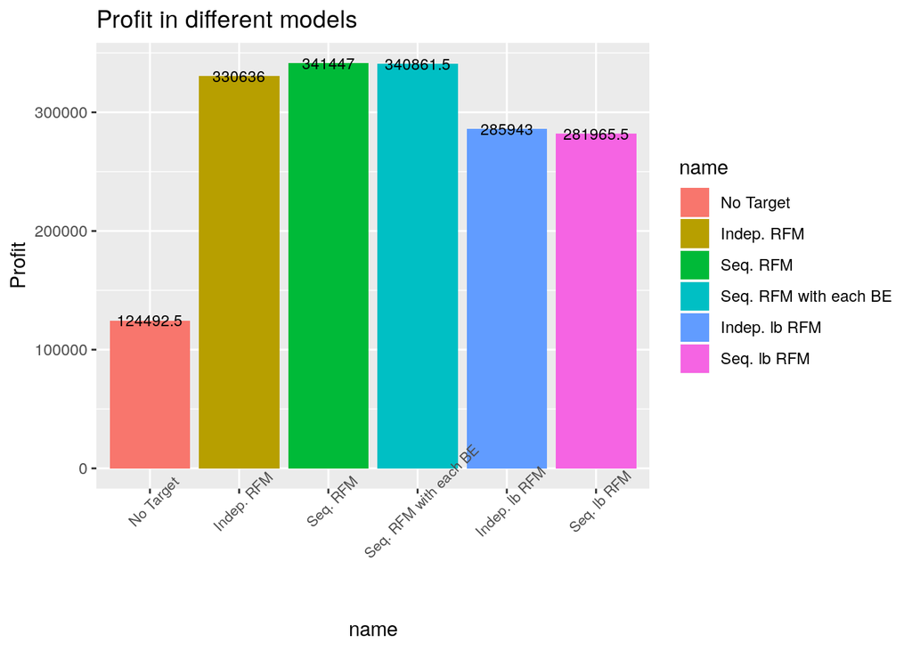

```r
## Create a bar chart with profit information
results %>%
  ggplot(aes(x = name, y = Profit, fill = name)) + geom_bar(stat = "identity") + geom_text(aes(label = round(Profit, 2)), size = 3) + labs(title = 'Profit in different models') + theme(axis.text.x  = element_text(size=8,angle=45))
```

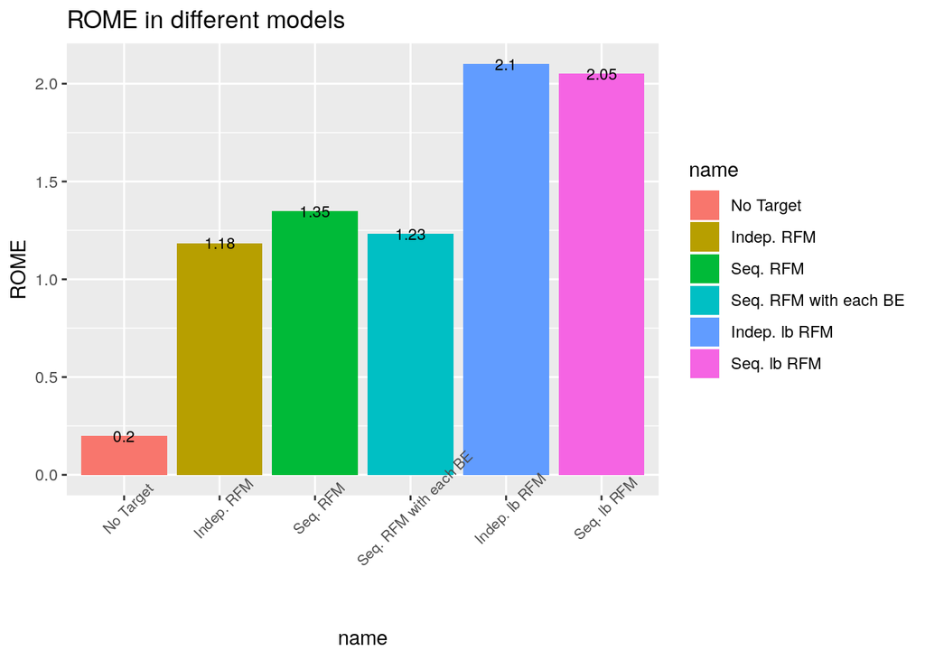

```r
## Create a bar chart with ROME information
results %>%
  ggplot(aes(x = name, y = ROME, fill = name)) + geom_bar(stat = "identity") + geom_text(aes(label = round(ROME, 2)), size = 3) + labs(title = 'ROME in different models') + theme(axis.text.x  = element_text(size=8,angle=45))
```